# Homework 3

Eunseo Kang

## Classification

For this assignment, we will be working with part of a [Kaggle data set](https://www.kaggle.com/c/titanic/overview) that was the subject of a machine learning competition and is often used for practicing ML models. The goal is classification; specifically, to predict which passengers would survive the [Titanic shipwreck](https://en.wikipedia.org/wiki/Titanic).

Load the data from `data/titanic.csv` into *R* and familiarize yourself with the variables it contains using the codebook (`data/titanic_codebook.txt`).

Notice that `survived` and `pclass` should be changed to factors. When changing `survived` to a factor, you may want to reorder the factor so that *“Yes”* is the first level.

Make sure you load the `tidyverse` and `tidymodels`!

*Remember that you’ll need to set a seed at the beginning of the document to reproduce your results.*

### Question 1

Split the data, stratifying on the outcome variable, `survived.` You should choose the proportions to split the data into. Verify that the training and testing data sets have the appropriate number of observations. Take a look at the training data and note any potential issues, such as missing data.

Why is it a good idea to use stratified sampling for this data?

```r
data <- read.csv('data/titanic.csv')
data$survived <- factor(data$survived, levels=c("Yes","No"))
data$pclass <- factor(data$pclass)

set.seed(514222)

titanic_split <- initial_split(data, prop = 0.70,
                                strata = survived)
titanic_train <- training(titanic_split)
titanic_test <- testing(titanic_split)
```

- The proportion of training data is 0.6992144, which is approximately 0.7.

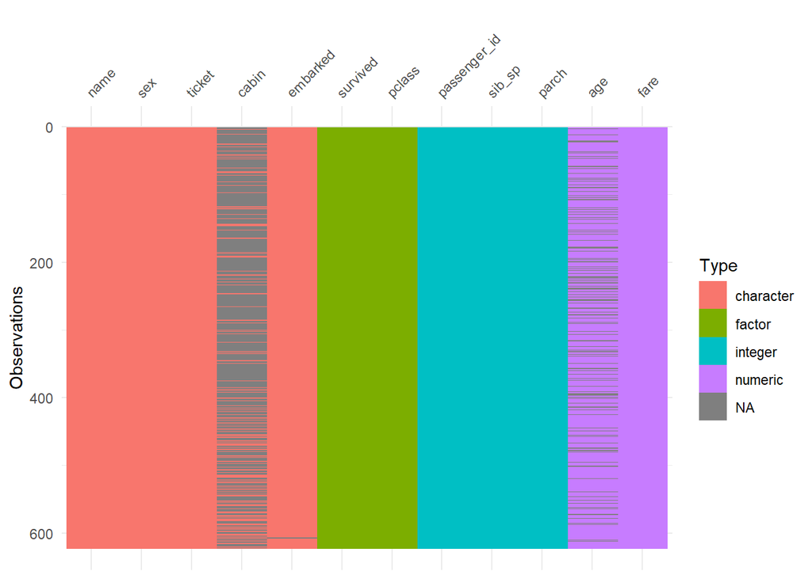

```r
#install.packages('visdat')
#install.packages('naniar')
library(naniar)
library(visdat)
vis_dat(titanic_train)
```

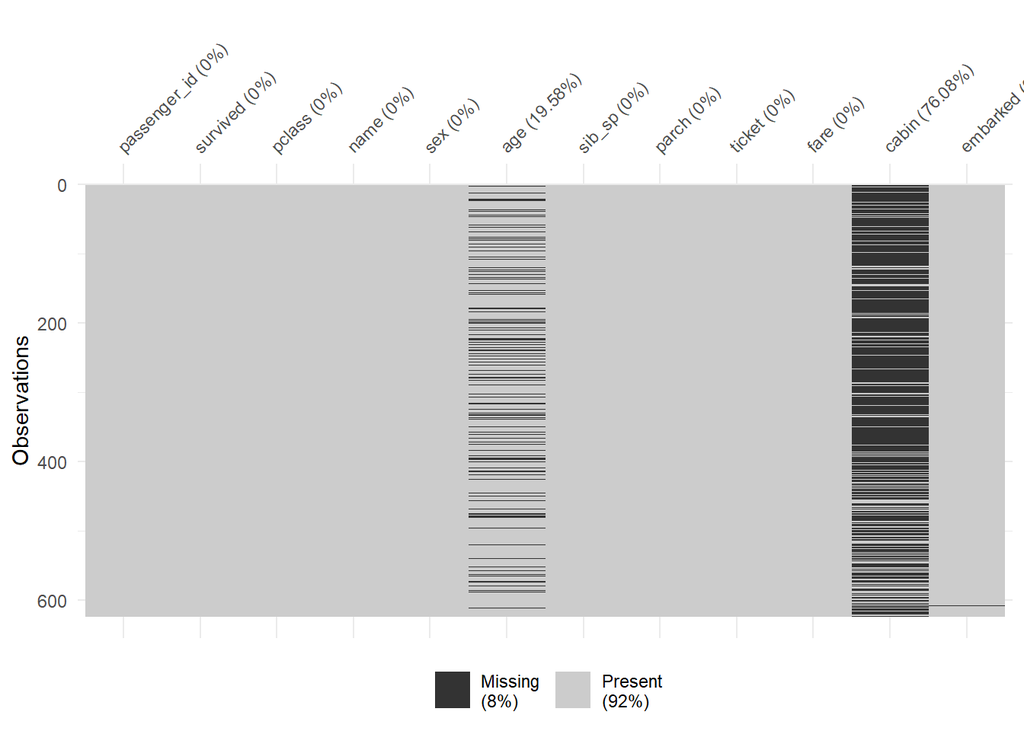

```r
vis_miss(titanic_train)
```

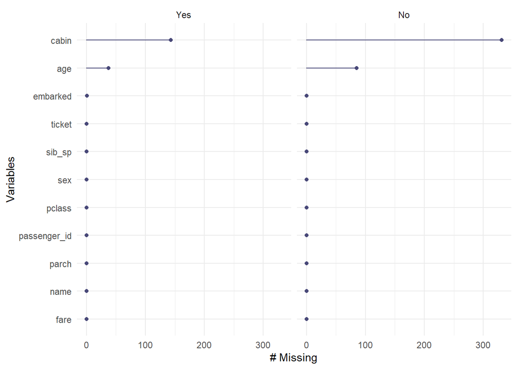

```r
gg_miss_var(titanic_train, facet = survived)
```

- It seems there are a lot of missing data in the variables for age and cabin. It is a good idea to stratify the samples since there are much more missing data when the strata is ‘No’ for ‘survived’ variable as shown in the above plot.

### Question 2

Using the **training** data set, explore/describe the distribution of the outcome variable `survived`.

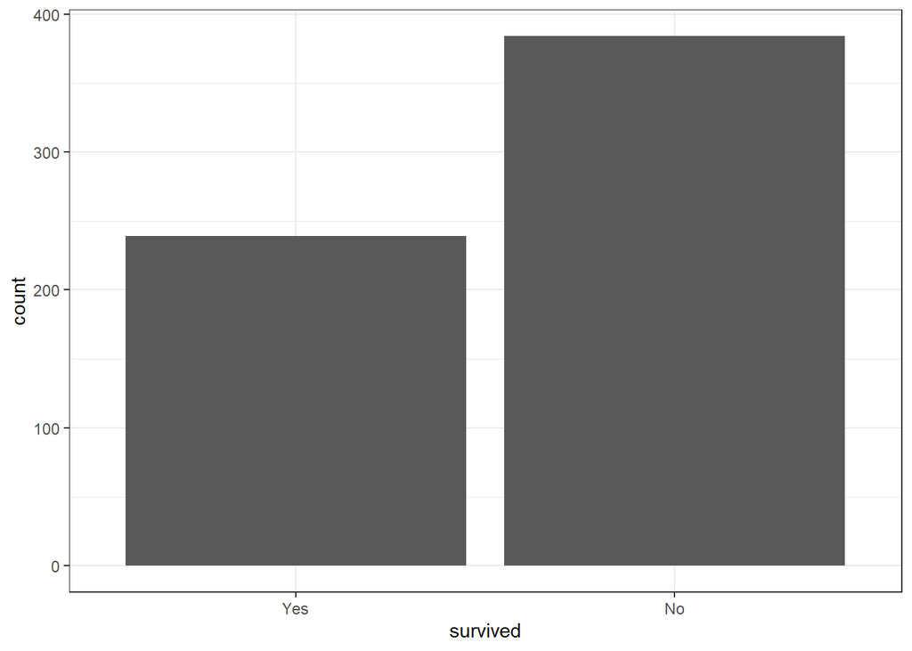

```r
titanic_train %>%
  ggplot(aes(x=survived)) +
  geom_bar() +
  theme_bw()
```

- The distribution of the variable ‘survived’ is more concentrated in non-survived passengers. The number of non-survived passengers are almost 1.5 times of the number of survived passengers.

### Question 3

Using the **training** data set, create a correlation matrix of all continuous variables. Create a visualization of the matrix, and describe any patterns you see. Are any predictors correlated with each other? Which ones, and in which direction?

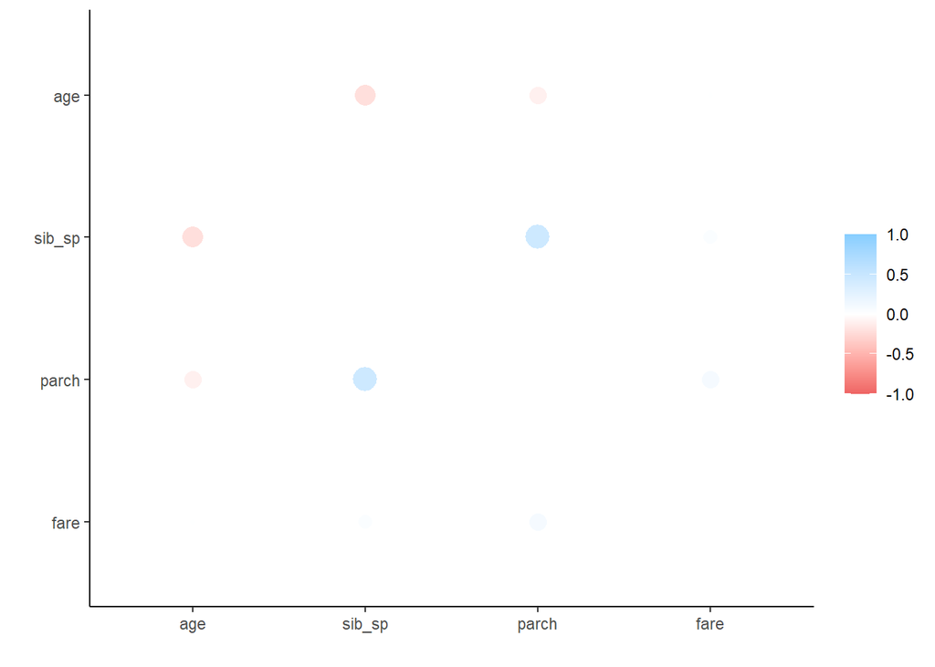

```r
cor_titanic <- titanic_train %>%
  select(-passenger_id) %>%
  correlate()
rplot(cor_titanic)
```

- The only continuous numeric variables are age, the number of siblings or souse, the number of parents or children, and fare. The figure shows there is a slight positive correlation between the number of the number of siblings or spouse and the number of parents or children, which suggests that there were passengers traveling with the family. In addition, there seems slight negative correlation between the age and the number of siblings or spouse since the youger a passenger is, the lower the probability to be married or to have siblings is. In a similar vein, there is a smaller negative correlation between the age and the number of parents or children, which might be less likelihood to have children at young age.

### Question 4

Using the **training** data, create a recipe predicting the outcome variable `survived`. Include the following predictors: ticket class, sex, age, number of siblings or spouses aboard, number of parents or children aboard, and passenger fare.

Recall that there were missing values for `age`. To deal with this, add an imputation step using `step_impute_linear()`. Next, use `step_dummy()` to **dummy** encode categorical predictors. Finally, include interactions between:

- Sex and passenger fare, and
- Age and passenger fare.

You’ll need to investigate the `tidymodels` documentation to find the appropriate step functions to use.

```r
unique(titanic_train$sex) %>% sort()
```

```
## [1] "female" "male"
```

```r
titanic_recipe <- recipe(survived ~ pclass+sex+age+sib_sp+parch+fare, data = titanic_train) %>%
  step_impute_linear(age) %>%
  step_dummy(sex) %>%
  step_interact(terms=~fare:starts_with("sex")+age:starts_with("sex"))
```

### Question 5

Specify a **logistic regression** model for classification using the `"glm"` engine. Then create a workflow. Add your model and the appropriate recipe. Finally, use `fit()` to apply your workflow to the **training** data.

*Hint: Make sure to store the results of `fit()`. You’ll need them later on.*

```r
log_fit <- logistic_reg() %>%
  set_engine("glm") %>%
  set_mode("classification")

log_wkflow <- workflow() %>%
  add_model(log_fit) %>%
  add_recipe(titanic_recipe)

log_fit <-  fit(log_wkflow, titanic_train)

log_fit %>%
  tidy()
```

```
## # A tibble: 10 × 5
##    term             estimate std.error statistic  p.value
##    <chr>               <dbl>     <dbl>     <dbl>    <dbl>
##  1 (Intercept)     -3.51       0.615     -5.71   1.14e- 8
##  2 pclass2          1.47       0.396      3.71   2.07e- 4
##  3 pclass3          2.68       0.386      6.93   4.27e-12
##  4 age              0.000535   0.0146     0.0366 9.71e- 1
##  5 sib_sp           0.491      0.144      3.42   6.20e- 4
##  6 parch            0.0882     0.146      0.603  5.47e- 1
##  7 fare             0.000247   0.00576    0.0428 9.66e- 1
##  8 sex_male         1.49       0.578      2.57   1.01e- 2
##  9 fare_x_sex_male -0.00200    0.00587   -0.341  7.33e- 1
## 10 sex_male_x_age   0.0627     0.0194     3.24   1.20e- 3
```

### Question 6

**Repeat Question 5**, but this time specify a linear discriminant analysis model for classification using the `"MASS"` engine.

```r
lda_mod <- discrim_linear() %>%
  set_mode("classification") %>%
  set_engine("MASS")

lda_wkflow <- workflow() %>%
  add_model(lda_mod) %>%
  add_recipe(titanic_recipe)

lda_fit <- fit(lda_wkflow, titanic_train)
```

### Question 7

**Repeat Question 5**, but this time specify a quadratic discriminant analysis model for classification using the `"MASS"` engine.

```r
qda_mod <- discrim_quad() %>%
  set_mode("classification") %>%
  set_engine("MASS")

qda_wkflow <- workflow() %>%
  add_model(qda_mod) %>%
  add_recipe(titanic_recipe)

qda_fit <- fit(qda_wkflow, titanic_train)
```

### Question 8

**Repeat Question 5**, but this time specify a naive Bayes model for classification using the `"klaR"` engine. Set the `usekernel` argument to `FALSE`.

```r
nb_mod <- naive_Bayes() %>%
  set_mode("classification") %>%
  set_engine("klaR") %>%
  set_args(usekernel = FALSE)

nb_wkflow <- workflow() %>%
  add_model(nb_mod) %>%
  add_recipe(titanic_recipe)

nb_fit <- fit(nb_wkflow, titanic_train)
```

### Question 9

Now you’ve fit four different models to your training data.

Use `predict()` and `bind_cols()` to generate predictions using each of these 4 models and your **training** data. Then use the *accuracy* metric to assess the performance of each of the four models.

Which model achieved the highest accuracy on the training data?

```r
log_predict <- predict(log_fit, new_data = titanic_train, type = "prob")
lda_predict <- predict(lda_fit, new_data = titanic_train, type = "prob")
qda_predict <- predict(qda_fit, new_data = titanic_train, type = "prob")
nb_predict <- predict(nb_fit, new_data = titanic_train, type = "prob")
predict <- bind_cols(log_predict, lda_predict, qda_predict, nb_predict)
predict
```

```
## # A tibble: 623 × 8
##    .pred_Yes...1 .pred_No...2 .pred_Yes...3 .pred_No...4 .pred_Yes...5
##            <dbl>        <dbl>         <dbl>        <dbl>         <dbl>
##  1        0.0741        0.926       0.0383         0.962   0.00183
##  2        0.0783        0.922       0.0407         0.959   0.00416
##  3        0.214         0.786       0.142          0.858   0.00126
##  4        0.0906        0.909       0.0500         0.950   0.000000193
##  5        0.129         0.871       0.0707         0.929   0.00388
##  6        0.0180        0.982       0.00959        0.990   0.574
##  7        0.695         0.305       0.768          0.232   0.870
##  8        0.166         0.834       0.112          0.888   0.00805
##  9        0.323         0.677       0.381          0.619   0.00764
## 10        0.409         0.591       0.458          0.542   1.00
## # … with 613 more rows, and 3 more variables: .pred_No...6 <dbl>,
## #   .pred_Yes...7 <dbl>, .pred_No...8 <dbl>
```

```r
log_reg_acc <- augment(log_fit, new_data = titanic_train) %>%
  accuracy(truth = survived, estimate = .pred_class)
lda_acc <- augment(lda_fit, new_data = titanic_train) %>%
  accuracy(truth = survived, estimate = .pred_class)
qda_acc <- augment(qda_fit, new_data = titanic_train) %>%
  accuracy(truth = survived, estimate = .pred_class)
nb_acc <- augment(nb_fit, new_data = titanic_train) %>%
  accuracy(truth = survived, estimate = .pred_class)

accuracies <- c(log_reg_acc$.estimate, lda_acc$.estimate,
                nb_acc$.estimate, qda_acc$.estimate)

models <- c("Logistic Regression", "LDA", "Naive Bayes", "QDA")

results <- tibble(accuracies = accuracies, models = models)

results %>%
  arrange(-accuracies)
```

```
## # A tibble: 4 × 2
##   accuracies models
##        <dbl> <chr>
## 1      0.822 Logistic Regression
## 2      0.819 LDA
## 3      0.806 Naive Bayes
## 4      0.793 QDA
```

- The accuracy for the logistic regression is the highest on the training data.

### Question 10

Fit the model with the highest training accuracy to the **testing** data. Report the accuracy of the model on the **testing** data.

Again using the **testing** data, create a confusion matrix and visualize it. Plot an ROC curve and calculate the area under it (AUC).

How did the model perform? Compare its training and testing accuracies. If the values differ, why do you think this is so?

```r
predict(log_fit, new_data = titanic_test, type = "prob")
```

```
## # A tibble: 268 × 2
##    .pred_Yes .pred_No
##        <dbl>    <dbl>
##  1    0.0544   0.946
##  2    0.822    0.178
##  3    0.970    0.0301
##  4    0.0582   0.942
##  5    0.579    0.421
##  6    0.694    0.306
##  7    0.171    0.829
##  8    0.695    0.305
##  9    0.0780   0.922
## 10    0.951    0.0491
## # … with 258 more rows
```

```r
multi_metric <- metric_set(accuracy, sensitivity, specificity)

augment(log_fit, new_data = titanic_test) %>%
  multi_metric(truth = survived, estimate = .pred_class)
```

```
## # A tibble: 3 × 3
##   .metric     .estimator .estimate
##   <chr>       <chr>          <dbl>
## 1 accuracy    binary         0.769
## 2 sensitivity binary         0.612
## 3 specificity binary         0.867
```

*The accuracy for the testing data is 0.7686567.

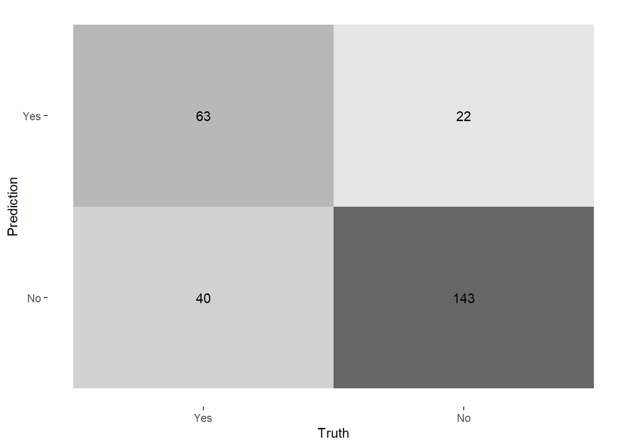

```r
augment(log_fit, new_data = titanic_test) %>%
  conf_mat(truth = survived, estimate = .pred_class) %>%
  autoplot(type = "heatmap")
```

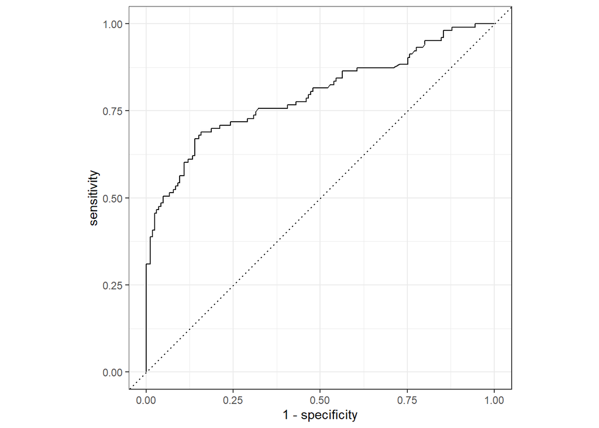

```r
augment(log_fit, new_data = titanic_test) %>%
  roc_curve(survived, .pred_Yes) %>%
  autoplot()
```

```r
augment(log_fit, new_data = titanic_test) %>%
  roc_auc(survived, .pred_Yes)
```

```
## # A tibble: 1 × 3
##   .metric .estimator .estimate
##   <chr>   <chr>          <dbl>
## 1 roc_auc binary         0.795
```

- The area under the curve is 0.7950868. Since AUC is quite close to 1, the model perform quite well. When comparing the training and testing accuracy, the training accuracy is bigger as expected, since the model is fit using training data.

### Required for 231 Students

In a binary classification problem, let $p$ represent the probability of class label $1$, which implies that $1 - p$ represents the probability of class label $0$. The *logistic function* (also called the “inverse logit”) is the cumulative distribution function of the logistic distribution, which maps a real number *z* to the open interval $(0, 1)$.

### Question 11

Given that:

$$p(z)=\frac{e^z}{1+e^z}$$

Prove that the inverse of a logistic function is indeed the *logit* function:

$$z(p)=ln\left(\frac{p}{1-p}\right)$$

- Prove

$$1-p(z)=1/(1+e^z)$$
$$1/(1-p(z))=1+e^z$$
$$e^z=p(z)/(1-p(z))$$
$$\therefore z=ln(p/(1-p))$$

### Question 12

Assume that $z = \beta_0 + \beta_{1}x_{1}$ and $p = logistic(z)$. How do the odds of the outcome change if you increase $x_{1}$ by two? Demonstrate this.

- The odds of the outcome change when $x_{1}$ increases by two is $e^{2*\beta_{1}}$.

Assume now that $\beta_1$ is negative. What value does $p$ approach as $x_{1}$ approaches $\infty$? What value does $p$ approach as $x_{1}$ approaches $-\infty$?

- Since $\frac{p}{1-p}=e^{\beta_0 + \beta_{1}x_{1}}$, when $\beta_1$ is negative and $x_{1}$ approaches $\infty$, the right hand side approaches zero, which means $p$ also approaches zero. On the other hand, when $\beta_1$ is negative and $x_{1}$ approaches $-\infty$, the right hand side approaches infinity, which means that $p$ also approaches 1 so that the denominator in the lefthand side approaches zero.